# Titanic

## O Danych

Dane o pasażerach Titanica

Zbiór danych zawiera informacje o pasażerach RMS Titanic, który zatonął 15 kwietnia 1912 roku po zderzeniu z górą lodową. Dane obejmują takie atrybuty jak klasa podróży, wiek, płeć, liczba rodzeństwa/małżonków na pokładzie, liczba rodziców/dzieci na pokładzie, cena biletu oraz miejsce zaokrętowania.

Zbiór zawiera także informację o tym, czy pasażer przeżył katastrofę.

Titanic przewoził ponad 2,200 osób, z czego ponad 1,500 zginęło, co czyni tę katastrofę jedną z najbardziej tragicznych w historii morskiej.

Kolumny:

- **pclass** - Klasa biletu
- **survived** - Czy pasażer przeżył katastrofę
- **name** - Imię i nazwisko pasażera
- **sex** - Płeć pasażera
- **age** - Wiek pasażera
- **sibsp** - Liczba rodzeństwa/małżonków na pokładzie
- **parch** - Liczba rodziców/dzieci na pokładzie
- **ticket** - Numer biletu
- **fare** - Cena biletu
- **cabin** - Numer kabiny
- **embarked** - Port, w którym pasażer wszedł na pokład (C = Cherbourg, Q = Queenstown, S = Southampton)
- **boat** - Numer łodzi ratunkowej
- **body** - Numer ciała (jeśli pasażer nie przeżył i ciało zostało odnalezione)
- **home.dest** - Miejsce docelowe

[figure not shown]

# 1. Analiza wstepna

|  | pclass | survived | name | sex | age | sibsp | parch | ticket | fare | cabin | embarked | boat | body | home.dest |
| --- | --- | --- | --- | --- | --- | --- | --- | --- | --- | --- | --- | --- | --- | --- |
| 0 | 1.0 | 1.0 | Allen, Miss. Elisabeth Walton | female | 29.0000 | 0.0 | 0.0 | 24160 | 211.3375 | B5 | S | 2 | NaN | St Louis, MO |
| 1 | 1.0 | 1.0 | Allison, Master. Hudson Trevor | male | 0.9167 | 1.0 | 2.0 | 113781 | 151.5500 | C22 C26 | S | 11 | NaN | Montreal, PQ / Chesterville, ON |
| 2 | 1.0 | 0.0 | Allison, Miss. Helen Loraine | female | 2.0000 | 1.0 | 2.0 | 113781 | 151.5500 | C22 C26 | S | NaN | NaN | Montreal, PQ / Chesterville, ON |
| 3 | 1.0 | 0.0 | Allison, Mr. Hudson Joshua Creighton | male | 30.0000 | 1.0 | 2.0 | 113781 | 151.5500 | C22 C26 | S | NaN | 135.0 | Montreal, PQ / Chesterville, ON |
| 4 | 1.0 | 0.0 | Allison, Mrs. Hudson J C (Bessie Waldo Daniels) | female | 25.0000 | 1.0 | 2.0 | 113781 | 151.5500 | C22 C26 | S | NaN | NaN | Montreal, PQ / Chesterville, ON |
| ... | ... | ... | ... | ... | ... | ... | ... | ... | ... | ... | ... | ... | ... | ... |
| 1305 | 3.0 | 0.0 | Zabour, Miss. Thamine | female | NaN | 1.0 | 0.0 | 2665 | 14.4542 | NaN | C | NaN | NaN | NaN |
| 1306 | 3.0 | 0.0 | Zakarian, Mr. Mapriededer | male | 26.5000 | 0.0 | 0.0 | 2656 | 7.2250 | NaN | C | NaN | 304.0 | NaN |
| 1307 | 3.0 | 0.0 | Zakarian, Mr. Ortin | male | 27.0000 | 0.0 | 0.0 | 2670 | 7.2250 | NaN | C | NaN | NaN | NaN |
| 1308 | 3.0 | 0.0 | Zimmerman, Mr. Leo | male | 29.0000 | 0.0 | 0.0 | 315082 | 7.8750 | NaN | S | NaN | NaN | NaN |
| 1309 | NaN | NaN | NaN | NaN | NaN | NaN | NaN | NaN | NaN | NaN | NaN | NaN | NaN | NaN |

1310 rows × 14 columns

### Wgrajmy kilka razy 10 losowych rzedow w celu dokladniejszych obserwacji:

|  | pclass | survived | name | sex | age | sibsp | parch | ticket | fare | cabin | embarked | boat | body | home.dest |
| --- | --- | --- | --- | --- | --- | --- | --- | --- | --- | --- | --- | --- | --- | --- |
| 679 | 3.0 | 0.0 | Boulos, Miss. Nourelain | female | 9.0 | 1.0 | 1.0 | 2678 | 15.2458 | NaN | C | NaN | NaN | Syria Kent, ON |
| 1100 | 3.0 | 0.0 | Palsson, Mrs. Nils (Alma Cornelia Berglund) | female | 29.0 | 0.0 | 4.0 | 349909 | 21.0750 | NaN | S | NaN | 206.0 | NaN |
| 20 | 1.0 | 1.0 | Beckwith, Mr. Richard Leonard | male | 37.0 | 1.0 | 1.0 | 11751 | 52.5542 | D35 | S | 5 | NaN | New York, NY |
| 85 | 1.0 | 1.0 | Cumings, Mrs. John Bradley (Florence Briggs Th... | female | 38.0 | 1.0 | 0.0 | PC 17599 | 71.2833 | C85 | C | 4 | NaN | New York, NY |
| 994 | 3.0 | 0.0 | Mardirosian, Mr. Sarkis | male | NaN | 0.0 | 0.0 | 2655 | 7.2292 | F E46 | C | NaN | NaN | NaN |
| 585 | 2.0 | 0.0 | Weisz, Mr. Leopold | male | 27.0 | 1.0 | 0.0 | 228414 | 26.0000 | NaN | S | NaN | 293.0 | Bromsgrove, England / Montreal, PQ |
| 1072 | 3.0 | 0.0 | O'Connell, Mr. Patrick D | male | NaN | 0.0 | 0.0 | 334912 | 7.7333 | NaN | Q | NaN | NaN | NaN |
| 247 | 1.0 | 1.0 | Rothschild, Mrs. Martin (Elizabeth L. Barrett) | female | 54.0 | 1.0 | 0.0 | PC 17603 | 59.4000 | NaN | C | 6 | NaN | New York, NY |
| 1175 | 3.0 | 0.0 | Sage, Miss. Stella Anna | female | NaN | 8.0 | 2.0 | CA. 2343 | 69.5500 | NaN | S | NaN | NaN | NaN |
| 174 | 1.0 | 0.0 | Kent, Mr. Edward Austin | male | 58.0 | 0.0 | 0.0 | 11771 | 29.7000 | B37 | C | NaN | 258.0 | Buffalo, NY |

```
pclass          3
survived        2
name         1307
sex             2
age            98
sibsp           7
parch           8
ticket        929
fare          281
cabin         186
embarked        3
boat           27
body          121
home.dest     369
dtype: int64
```

### Zwraca uwage mala liczba 27 szalup ratunkowych. 186 kajut. 121 cial odnaleziono(na 1500). Ceny biletów wykazują aż 281 unikatowych wartości! Ciekawie byloby sprawdzić od czego zależy tak duża rozbieżność.

|  | pclass | survived | age | sibsp | parch | fare | body |
| --- | --- | --- | --- | --- | --- | --- | --- |
| count | 1309.000000 | 1309.000000 | 1046.000000 | 1309.000000 | 1309.000000 | 1308.000000 | 121.000000 |
| mean | 2.294882 | 0.381971 | 29.881135 | 0.498854 | 0.385027 | 33.295479 | 160.809917 |
| std | 0.837836 | 0.486055 | 14.413500 | 1.041658 | 0.865560 | 51.758668 | 97.696922 |
| min | 1.000000 | 0.000000 | 0.166700 | 0.000000 | 0.000000 | 0.000000 | 1.000000 |
| 25% | 2.000000 | 0.000000 | 21.000000 | 0.000000 | 0.000000 | 7.895800 | 72.000000 |
| 50% | 3.000000 | 0.000000 | 28.000000 | 0.000000 | 0.000000 | 14.454200 | 155.000000 |
| 75% | 3.000000 | 1.000000 | 39.000000 | 1.000000 | 0.000000 | 31.275000 | 256.000000 |
| max | 3.000000 | 1.000000 | 80.000000 | 8.000000 | 9.000000 | 512.329200 | 328.000000 |

```
<class 'pandas.core.frame.DataFrame'>
RangeIndex: 1310 entries, 0 to 1309
Data columns (total 14 columns):
 #   Column     Non-Null Count  Dtype
---  ------     --------------  -----
 0   pclass     1309 non-null   float64
 1   survived   1309 non-null   float64
 2   name       1309 non-null   object
 3   sex        1309 non-null   object
 4   age        1046 non-null   float64
 5   sibsp      1309 non-null   float64
 6   parch      1309 non-null   float64
 7   ticket     1309 non-null   object
 8   fare       1308 non-null   float64
 9   cabin      295 non-null    object
 10  embarked   1307 non-null   object
 11  boat       486 non-null    object
 12  body       121 non-null    float64
 13  home.dest  745 non-null    object
dtypes: float64(7), object(7)
memory usage: 143.4+ KB
```

### W szalupach ratunkowych bylo lacznie 486 osob

```
0.0    809
1.0    500
Name: survived, dtype: int64
```

### 500 pasazerow przezylo katastrofe, czyli 14 pasazerow nie bylo w szalupie ratunkowej i przezylo. Skoro odratowano 700 osób, w tym 500 pasażerów, przyjąć należy ze odratowano tez 200 członków załogi.

```
New York, NY                                    64
London                                          14
Montreal, PQ                                    10
Paris, France                                    9
Cornwall / Akron, OH                             9
                                                ..
Chelsea, London                                  1
Harrow-on-the-Hill, Middlesex                    1
Copenhagen, Denmark                              1
Guernsey / Montclair, NJ and/or Toledo, Ohio     1
Antwerp, Belgium / Stanton, OH                   1
Name: home.dest, Length: 369, dtype: int64
```

### Uwage zwracaja miejsca docelowe Londyn, Paryz i inne miasta europejskie. Sa to prawdopodobnie pasazerowie nie podrozujacy aby osiedlic sie w Ameryce, lecz plynacy na wycieczke i powracajacy pozniej do domu w Europie. Na taka podroz moglaby sobie pozwolic tylko 1 klasa, ewentualnie 2. Sprawdzmy te teze:

|  | pclass | survived | name | sex | age | sibsp | parch | ticket | fare | cabin | embarked | boat | body | home.dest |
| --- | --- | --- | --- | --- | --- | --- | --- | --- | --- | --- | --- | --- | --- | --- |
| 12 | 1.0 | 1.0 | Aubart, Mme. Leontine Pauline | female | 24.0 | 0.0 | 0.0 | PC 17477 | 69.3000 | B35 | C | 9 | NaN | Paris, France |
| 68 | 1.0 | 1.0 | Chevre, Mr. Paul Romaine | male | 45.0 | 0.0 | 0.0 | PC 17594 | 29.7000 | A9 | C | 7 | NaN | Paris, France |
| 133 | 1.0 | 1.0 | Goldenberg, Mr. Samuel L | male | 49.0 | 1.0 | 0.0 | 17453 | 89.1042 | C92 | C | 5 | NaN | Paris, France / New York, NY |
| 134 | 1.0 | 1.0 | Goldenberg, Mrs. Samuel L (Edwiga Grabowska) | female | NaN | 1.0 | 0.0 | 17453 | 89.1042 | C92 | C | 5 | NaN | Paris, France / New York, NY |
| 169 | 1.0 | 0.0 | Isham, Miss. Ann Elizabeth | female | 50.0 | 0.0 | 0.0 | PC 17595 | 28.7125 | C49 | C | NaN | NaN | Paris, France New York, NY |
| 187 | 1.0 | 1.0 | Lines, Miss. Mary Conover | female | 16.0 | 0.0 | 1.0 | PC 17592 | 39.4000 | D28 | S | 9 | NaN | Paris, France |
| 188 | 1.0 | 1.0 | Lines, Mrs. Ernest H (Elizabeth Lindsey James) | female | 51.0 | 0.0 | 1.0 | PC 17592 | 39.4000 | D28 | S | 9 | NaN | Paris, France |
| 196 | 1.0 | 1.0 | Marechal, Mr. Pierre | male | NaN | 0.0 | 0.0 | 11774 | 29.7000 | C47 | C | 7 | NaN | Paris, France |
| 219 | 1.0 | 1.0 | Omont, Mr. Alfred Fernand | male | NaN | 0.0 | 0.0 | F.C. 12998 | 25.7417 | NaN | C | 7 | NaN | Paris, France |
| 242 | 1.0 | 1.0 | Rosenbaum, Miss. Edith Louise | female | 33.0 | 0.0 | 0.0 | PC 17613 | 27.7208 | A11 | C | 11 | NaN | Paris, France |
| 276 | 1.0 | 0.0 | Spencer, Mr. William Augustus | male | 57.0 | 1.0 | 0.0 | PC 17569 | 146.5208 | B78 | C | NaN | NaN | Paris, France |
| 277 | 1.0 | 1.0 | Spencer, Mrs. William Augustus (Marie Eugenie) | female | NaN | 1.0 | 0.0 | PC 17569 | 146.5208 | B78 | C | 6 | NaN | Paris, France |

### Teza potwierdzila sie, wszyscy Paryzanie to pasazerowie 1 klasy

|  | pclass | survived | name | sex | age | sibsp | parch | ticket | fare | cabin | embarked | boat | body | home.dest |
| --- | --- | --- | --- | --- | --- | --- | --- | --- | --- | --- | --- | --- | --- | --- |
| 0 | 1.0 | 1.0 | Allen, Miss. Elisabeth Walton | female | 29.0000 | 0.0 | 0.0 | 24160 | 211.3375 | B5 | S | 2 | NaN | St Louis, MO |
| 1 | 1.0 | 1.0 | Allison, Master. Hudson Trevor | male | 0.9167 | 1.0 | 2.0 | 113781 | 151.5500 | C22 C26 | S | 11 | NaN | Montreal, PQ / Chesterville, ON |
| 2 | 1.0 | 0.0 | Allison, Miss. Helen Loraine | female | 2.0000 | 1.0 | 2.0 | 113781 | 151.5500 | C22 C26 | S | NaN | NaN | Montreal, PQ / Chesterville, ON |
| 3 | 1.0 | 0.0 | Allison, Mr. Hudson Joshua Creighton | male | 30.0000 | 1.0 | 2.0 | 113781 | 151.5500 | C22 C26 | S | NaN | 135.0 | Montreal, PQ / Chesterville, ON |
| 4 | 1.0 | 0.0 | Allison, Mrs. Hudson J C (Bessie Waldo Daniels) | female | 25.0000 | 1.0 | 2.0 | 113781 | 151.5500 | C22 C26 | S | NaN | NaN | Montreal, PQ / Chesterville, ON |
| 5 | 1.0 | 1.0 | Anderson, Mr. Harry | male | 48.0000 | 0.0 | 0.0 | 19952 | 26.5500 | E12 | S | 3 | NaN | New York, NY |
| 6 | 1.0 | 1.0 | Andrews, Miss. Kornelia Theodosia | female | 63.0000 | 1.0 | 0.0 | 13502 | 77.9583 | D7 | S | 10 | NaN | Hudson, NY |
| 7 | 1.0 | 0.0 | Andrews, Mr. Thomas Jr | male | 39.0000 | 0.0 | 0.0 | 112050 | 0.0000 | A36 | S | NaN | NaN | Belfast, NI |
| 8 | 1.0 | 1.0 | Appleton, Mrs. Edward Dale (Charlotte Lamson) | female | 53.0000 | 2.0 | 0.0 | 11769 | 51.4792 | C101 | S | D | NaN | Bayside, Queens, NY |
| 9 | 1.0 | 0.0 | Artagaveytia, Mr. Ramon | male | 71.0000 | 0.0 | 0.0 | PC 17609 | 49.5042 | NaN | C | NaN | 22.0 | Montevideo, Uruguay |

### Zwróciła moja uwagę 4 osoby o nazwisku Allison, mieszkający w tych samych kajutach: ojciec (30 lat), matka (25 lat),2-letnia dziewczynka i prawie roczny chłopiec. Ktoś prawdopodobnie zaopiekował się chłopcem, ponieważ tylko on z całej czwórki przeżył katastrofę.

### Przypatrzmy sie jeszcze szalupom ratunkowym:

```
13         39
C          38
15         37
14         33
4          31
10         29
5          27
3          26
9          25
11         25
16         23
8          23
7          23
D          20
6          20
12         19
2          13
A          11
B           9
1           5
5 7         2
C D         2
13 15       2
5 9         1
8 10        1
13 15 B     1
15 16       1
Name: boat, dtype: int64
```

# 2. Brakujace wartosci

```
pclass          1
survived        1
name            1
sex             1
age           264
sibsp           1
parch           1
ticket          1
fare            2
cabin        1015
embarked        3
boat          824
body         1189
home.dest     565
dtype: int64
```

### Wszystkie wartosci, z wyjatkiem age, cabin, boat and body zastapie 'Unknown', age zastapie mediana w pozniejszym kroku. Celowo nie robie tego teraz, gdyz chce miec mozliwie najprawdziwsze dane do analizy

# 3. Eksplorujemy poszczegolne kolumny

## Na tym etapie chece przesledzic przezywalnosc i jakie okolicznosci na nia wplynely.

### Sprawdzmy, czy klasa biletu miala znaczenie jesli chodzi o przezywalnosc:

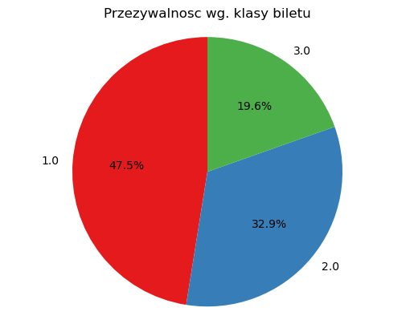

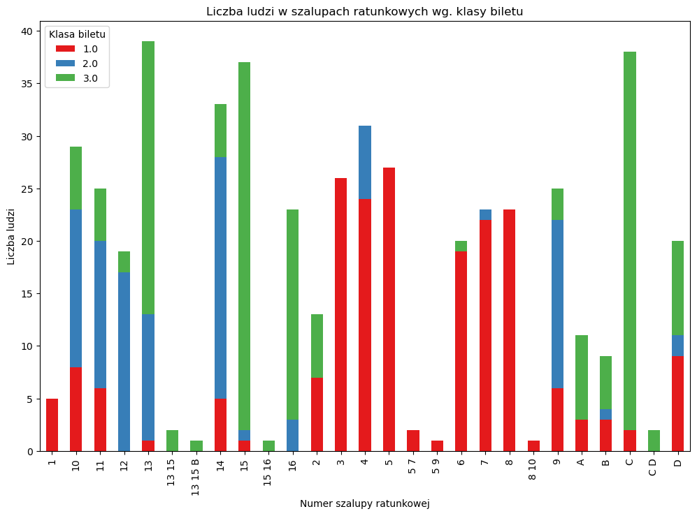

### Sprawdzmy teraz przezywalnosc jesli chodzi o plec:

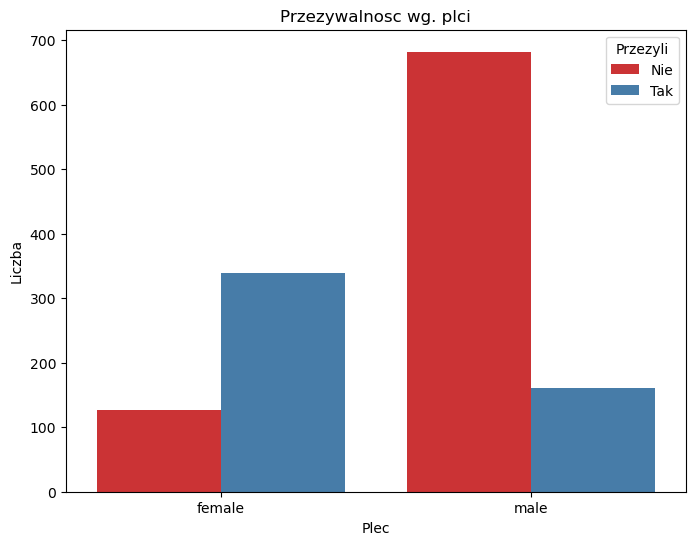

### Wyraznie widac ze duzo wieksza szanse na przezycie mialy kobiety

### Sprawdzmy teraz przezywalnosc jesli chodzi o dzieci 1, 2, i 3 klasy:

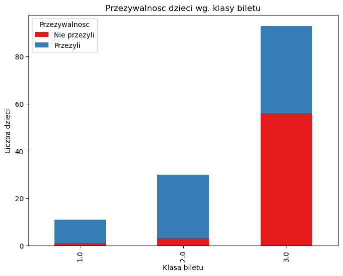

### Z powyzszego wykresu wynika, ze dzieci do 16 roku zycia i 1 i 2 klasy, mialy bardzo duza szanse przezycia. U dzieci w 3 klasie nie widac tej zaleznosci: wiecej dzieci w 3 klasie zginelo niz przezylo

# 4. Relacje miedzy kolumnami

### Przyjrzyjmy sie blizej przezywalnosci, jesli chodzi o plec i klase biletu:

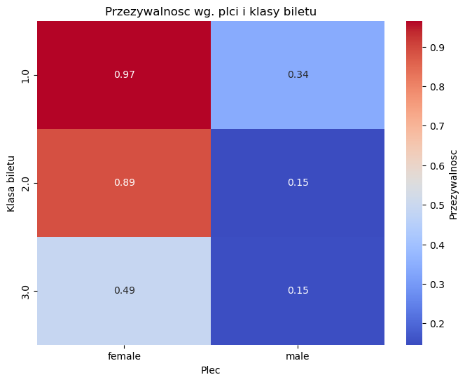

### Widac ze najwieksza szanse na przezycie mialy kobiety 1 i 2 klasy, kobiety 3 klasy mialy juz mala szanse, a mezczyzni 1 klasy jeszcze mniejsza szanse na przezycie. Mezczyzni 2 i 3 klasy praktycznie nie mieli szansy przezycia

# 5. Poszukiwanie wartosci odstajacych

### Narysujmy wykresy ceny biletu i przezywalnosci:

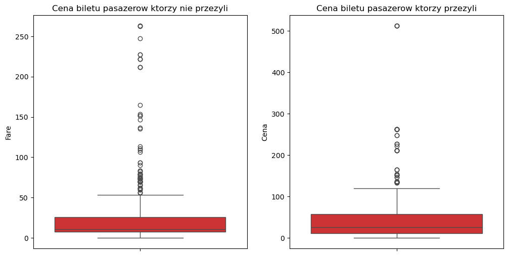

### Przyjmujac, ze cena zalezala od klasy biletu i pamietajac ze pierwsza klasa byla wyraznie preferowana jesli chodzi o dostep do lodzi ratunkowych,przykuwa uwage duza liczba wartosci odstajacych u pasazerow ktorzy nie przezyli. Sa to prawdopodobnie mezczyzni 1 klasy, ktorzy odstapili miejsca w szalupach ratunkowych kobietom i dzieciom

# 6. Transformacja danych / naprawa bledow

### Wszystkie wartosci, z wyjatkiem age, cabin, boat and body zastapie 'Unknown', age zastapie mediana

|  | pclass | survived | name | sex | age | sibsp | parch | ticket | fare | cabin | embarked | boat | body | home.dest |
| --- | --- | --- | --- | --- | --- | --- | --- | --- | --- | --- | --- | --- | --- | --- |
| 0 | 1.0 | 1.0 | Allen, Miss. Elisabeth Walton | female | 29.0000 | 0.0 | 0.0 | 24160 | 211.3375 | B5 | S | 2 | NaN | St Louis, MO |
| 1 | 1.0 | 1.0 | Allison, Master. Hudson Trevor | male | 0.9167 | 1.0 | 2.0 | 113781 | 151.55 | C22 C26 | S | 11 | NaN | Montreal, PQ / Chesterville, ON |
| 2 | 1.0 | 0.0 | Allison, Miss. Helen Loraine | female | 2.0000 | 1.0 | 2.0 | 113781 | 151.55 | C22 C26 | S | NaN | NaN | Montreal, PQ / Chesterville, ON |
| 3 | 1.0 | 0.0 | Allison, Mr. Hudson Joshua Creighton | male | 30.0000 | 1.0 | 2.0 | 113781 | 151.55 | C22 C26 | S | NaN | 135.0 | Montreal, PQ / Chesterville, ON |
| 4 | 1.0 | 0.0 | Allison, Mrs. Hudson J C (Bessie Waldo Daniels) | female | 25.0000 | 1.0 | 2.0 | 113781 | 151.55 | C22 C26 | S | NaN | NaN | Montreal, PQ / Chesterville, ON |
| ... | ... | ... | ... | ... | ... | ... | ... | ... | ... | ... | ... | ... | ... | ... |
| 1305 | 3.0 | 0.0 | Zabour, Miss. Thamine | female | 28.0000 | 1.0 | 0.0 | 2665 | 14.4542 | NaN | C | NaN | NaN | Unknown |
| 1306 | 3.0 | 0.0 | Zakarian, Mr. Mapriededer | male | 26.5000 | 0.0 | 0.0 | 2656 | 7.225 | NaN | C | NaN | 304.0 | Unknown |
| 1307 | 3.0 | 0.0 | Zakarian, Mr. Ortin | male | 27.0000 | 0.0 | 0.0 | 2670 | 7.225 | NaN | C | NaN | NaN | Unknown |
| 1308 | 3.0 | 0.0 | Zimmerman, Mr. Leo | male | 29.0000 | 0.0 | 0.0 | 315082 | 7.875 | NaN | S | NaN | NaN | Unknown |
| 1309 | Unknown | Unknown | Unknown | Unknown | 28.0000 | Unknown | Unknown | Unknown | Unknown | NaN | Unknown | NaN | NaN | Unknown |

1310 rows × 14 columns

# **Podsumowanie**

### 5. Widac ze **najwieksza szanse na przezycie** mialy **kobiety i dzieci 1 i 2 klasy** - to ich przepuszczano przodem do szalup ratunkowych i one miały praktycznie całkowite szanse na przetrwanie. Kobiety i dzieci 3 klasy mialy juz mala szanse, a mezczyzni 1 klasy jeszcze mniejsza szanse na przezycie. **Mezczyzni 2 i 3 klasy praktycznie nie mieli szansy przetrwania**.

### 6. Jest 1 tajemniczy pasażer (1309) o którym nic nie wiadomo. Być może to on posłużył jako inspiracja dla charakteru Jacka, z filmu Jamesa Camerona?

[figure not shown]

Infografika układu łodzi ratunkowych Titanica. Kropki oznaczają liczbę osób na łodzi i maksymalną pojemność.